# Clase 4 - R web scraping

## Preprocesamiento

Vamos a normalizar, primero, los campos de texto. Con esta instrucción cambiamos el encoding de texto de los campos `text` y `title` y lo pasamos a ASCII. Esta es una forma bastante rápida de eliminar tildes, ñ y otros acentos.

```r
revistas <- revistas %>%
                mutate(text = stringi::stri_trans_general(text, "Latin-ASCII"),
                       titulo = stringi::stri_trans_general(titulo, "Latin-ASCII"))
```

Eliminamos los dígitos que encontremos en el texto…

```r
revistas <- revistas %>%
          mutate(text = str_replace_all(text, '[[:digit:]]+', ''))
```

Ahora podemos tokenizarlo:

```r
revistas_tidy <- revistas %>%
                unnest_tokens(word, text)

head(revistas_tidy)
```

```
## # A tibble: 6 × 5
##      id categoria fecha                 titulo                             word
##   <dbl> <chr>     <chr>                 <chr>                              <chr>
## 1     1 Hombre    4  de marzo de 2018   Los ex caddies que se organizaron… ning…
## 2     1 Hombre    4  de marzo de 2018   Los ex caddies que se organizaron… tenia
## 3     1 Hombre    4  de marzo de 2018   Los ex caddies que se organizaron… la
## 4     1 Hombre    4  de marzo de 2018   Los ex caddies que se organizaron… plata
## 5     1 Hombre    4  de marzo de 2018   Los ex caddies que se organizaron… nece…
## 6     1 Hombre    4  de marzo de 2018   Los ex caddies que se organizaron… ni
```

Hagamos una exploración rápida:

```r
revistas_tidy %>%
        group_by(word) %>%
        summarise(n=n()) %>%
        arrange(desc(n))
```

```
## # A tibble: 112,083 × 2
##    word       n
##    <chr>  <int>
##  1 de    152420
##  2 que    89337
##  3 la     86281
##  4 y      85932
##  5 en     70293
##  6 el     67110
##  7 a      53494
##  8 un     37559
##  9 los    36885
## 10 con    34517
## # ℹ 112,073 more rows
```

Vemos que, claramente, tenemos que hacer una limpieza de stopwords.

```r
stop_words <- read_delim('./data/stopwords.txt',
                         delim = '\t',
                         col_names = c('word')) %>%
                        mutate(word=stringi::stri_trans_general(word, "Latin-ASCII"))
## Aquí agregamos algunas palabras al listado de stopwords...
stop_words <- stop_words %>%
                bind_rows( tibble(word=c('ano', 'anos', 'ohlala', 'foto', 'the')))

## Ahora, las eliminamos
revistas_tidy <- revistas_tidy %>%
                anti_join(stop_words)
```

Veamos cómo quedó ahora la distribución de palabras:

```r
revistas_tidy %>%
        group_by(word) %>%
        summarise(n=n()) %>%
        arrange(desc(n))
```

```
## # A tibble: 111,484 × 2
##    word          n
##    <chr>     <int>
##  1 vida       2835
##  2 mundo      2780
##  3 casa       1925
##  4 argentina  1729
##  5 forma      1674
##  6 historia   1486
##  7 personas   1462
##  8 ciudad     1412
##  9 podes      1392
## 10 tipo       1391
## # ℹ 111,474 more rows
```

#### Pregunta

¿Cómo podríamos identificar las palabras más usadas cada grupo de revista?

```r
revistas_tidy %>%
        group_by(categoria,word) %>%
        summarise(n=n()) %>%
        arrange(desc(n))
```

```
## # A tibble: 144,582 × 3
## # Groups:   categoria [2]
##    categoria word          n
##    <chr>     <chr>     <int>
##  1 Hombre    mundo      1652
##  2 Mujer     vida       1546
##  3 Hombre    argentina  1322
##  4 Hombre    vida       1289
##  5 Mujer     podes      1226
##  6 Mujer     mundo      1128
##  7 Mujer     vas        1009
##  8 Mujer     vos         971
##  9 Mujer     casa        963
## 10 Hombre    casa        962
## # ℹ 144,572 more rows
```

```r
hombres <- revistas_tidy %>%
        group_by(categoria,word) %>%
        summarise(n=n()) %>%
        arrange(desc(n)) %>%
        filter(categoria == "Hombre")
head(hombres)
```

```
## # A tibble: 6 × 3
## # Groups:   categoria [1]
##   categoria word          n
##   <chr>     <chr>     <int>
## 1 Hombre    mundo      1652
## 2 Hombre    argentina  1322
## 3 Hombre    vida       1289
## 4 Hombre    casa        962
## 5 Hombre    historia    947
## 6 Hombre    ciudad      921
```

```r
mujeres <- revistas_tidy %>%
        group_by(categoria,word) %>%
        summarise(n=n()) %>%
        arrange(desc(n)) %>%
        filter(categoria == "Mujer")
head(mujeres)
```

```
## # A tibble: 6 × 3
## # Groups:   categoria [1]
##   categoria word      n
##   <chr>     <chr> <int>
## 1 Mujer     vida   1546
## 2 Mujer     podes  1226
## 3 Mujer     mundo  1128
## 4 Mujer     vas    1009
## 5 Mujer     vos     971
## 6 Mujer     casa    963
```

Ahora sí, estamos en condiciones de avanzar en nuestro modelado de tópicos.

### Modelado de tópicos

Para hacer el modelado de temas como se implementa aquí, necesitamos generar una `DocumentTermMatrix`, un tipo especial de matriz del paquete tm (por supuesto, esto es solo una implementación específica del concepto general de una TFM).

Las filas corresponden a documentos (textos descriptivos en nuestro caso) y las columnas corresponden a términos (es decir, palabras); es una matriz dispersa y los valores son recuentos de palabras. Primero, generamos nuestra tabla tidy de conteos

```r
word_counts <- revistas_tidy %>%
        group_by(id, word) %>%
        summarise(n=n()) %>%
        ungroup()
```

[output not shown]

```r
head(word_counts)
```

```
## # A tibble: 6 × 3
##      id word            n
##   <dbl> <chr>       <int>
## 1     1 aag             2
## 2     1 abajo           2
## 3     1 abandonarlo     1
## 4     1 abierto         1
## 5     1 abiertos        1
## 6     1 abre            1
```

Tenemos hasta aquí nuestra estructura de datos habitual: un token por fila y una columna de conteo. Vamos a transformarla ahora a una TFM:

```r
disc_dtm <- word_counts %>%
                cast_dtm(id, word, n)

disc_dtm
```

```
## <<DocumentTermMatrix (documents: 3930, terms: 111484)>>
## Non-/sparse entries: 889157/437242963
## Sparsity           : 100%
## Maximal term length: NA
## Weighting          : term frequency (tf)
```

Vemos que este conjunto de datos contiene documentos (cada uno de ellos un discurso) y términos (palabras). Observe que esta matriz de documento-término de ejemplo es (muy cercana a) 100% dispersa, lo que significa que casi todas las entradas en esta matriz son cero. Cada entrada distinta de cero corresponde a una determinada palabra que aparece en un determinado documento.

### Ahora sí, vamos a modelar los tópicos

Ahora usemos el paquete `topicmodels` para estimar un modelo LDA. ¿Cuántos temas le diremos al algoritmo que haga? Esta es una pregunta muy parecida a la de un clustering de k-medias. La respuesta es desilusionadora: no lo sabemos. No queda otra opción que ir probando. Por ahora y a los fines prácticos de esta primera aproximación vamos a probar un modelo muy simple: 4 temas.

```r
lda_4 <- LDA(disc_dtm, k=4, control = list(seed = 1234))
```

Vemos que entrenar el modelo es simple: una línea de código. Lo difícil viene ahora.

### La interpretación

#### Probabilidad de cada palabra en cada tópico

```r
ap_topics <- tidy(lda_4, matrix = "beta") # Si esta línea  tira algún error,  install.packages("reshape2")

ap_topics
```

```
## # A tibble: 445,936 × 3
##    topic term             beta
##    <int> <chr>           <dbl>
##  1     1 aag         3.58e-147
##  2     2 aag         6.19e-  6
##  3     3 aag         4.47e-147
##  4     4 aag         5.28e- 12
##  5     1 abajo       9.58e-  5
##  6     2 abajo       2.48e-  4
##  7     3 abajo       3.06e-  4
##  8     4 abajo       7.14e-  5
##  9     1 abandonarlo 2.06e- 17
## 10     2 abandonarlo 9.28e-  6
## # ℹ 445,926 more rows
```

```r
unique(ap_topics$topic)
```

```
## [1] 1 2 3 4
```

La función `tidy`conviritó el modelo a un formato de un tópico-término por fila. Para cada combinación, el modelo calcula la probabilidad de que ese término se genere a partir de ese tópico.

Podríamos usar el `slice_max()` de `dplyr` para encontrar los 15 términos que son más comunes dentro de cada tema. Dado que tenemos una tibble, podemos usar una visualización de `ggplot2`.

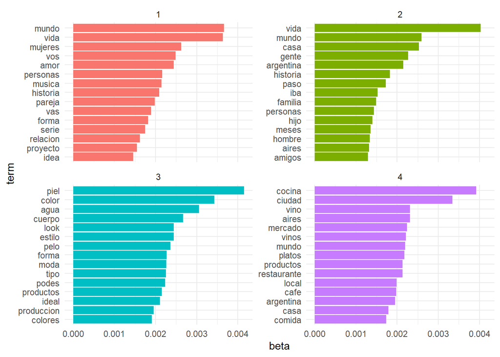

```r
ap_top_terms <- ap_topics %>%
  group_by(topic) %>%
  slice_max(beta, n = 15) %>%
  #ungroup() %>%
  arrange(topic, -beta)


ap_top_terms %>%
  mutate(term = reorder_within(term, beta, topic)) %>%
  ggplot(aes(beta, term, fill = factor(topic))) +
  geom_col(show.legend = FALSE) +
  facet_wrap(~ topic, scales='free_y') +
  scale_y_reordered() +
  theme_minimal()
```

Pareciera que hay dos conjuntos de palabras que tiene un tema bien definido: - el tema 3 parece hablar de cuestiones vinculadas al cuidado del cuerpo (dietas, moda, etc.) - el 4 parece hablar de restaurantes, comidas, vinos, etc.

En cambio, los temas 1 y 2 no parecen tener un sentido tan definido. El 1 parece hablar de cuestiones de pareja y el dos de viajes y familia.

#### Composición de tópicos por documento

Además de estimar cada tema como una mezcla de palabras, LDA también modela cada documento como una mezcla de temas. Podemos examinar las probabilidades por documento por tema, llamadas $\gamma$, con el argumento `matrix = "gamma"` para `tidy()`.

```r
options(scipen = 999)
doc_2_topics <- tidy(lda_4, matrix = "gamma")
doc_2_topics %>%
  mutate(gamma = round(gamma, 5))
```

```
## # A tibble: 15,720 × 3
##    document topic   gamma
##    <chr>    <int>   <dbl>
##  1 1            1 0.00005
##  2 2            1 0.00035
##  3 3            1 0.950
##  4 4            1 0.00038
##  5 5            1 0.00135
##  6 6            1 0.554
##  7 7            1 0.00011
##  8 8            1 0.430
##  9 9            1 0.00035
## 10 10           1 0.999
## # ℹ 15,710 more rows
```

Cada uno de estos valores es una proporción estimada de palabras de ese documento que se generan a partir de ese tema.

Veamos los tópicos 3 y 4:

```r
doc_2_topics %>%
  filter(topic == 3 | topic == 4) %>%
  mutate(gamma = round(gamma, 5))
```

```
## # A tibble: 7,860 × 3
##    document topic   gamma
##    <chr>    <int>   <dbl>
##  1 1            3 0.00005
##  2 2            3 0.00035
##  3 3            3 0.00036
##  4 4            3 0.00038
##  5 5            3 0.00135
##  6 6            3 0.00015
##  7 7            3 0.00011
##  8 8            3 0.00019
##  9 9            3 0.450
## 10 10           3 0.0002
## # ℹ 7,850 more rows
```

```r
topicos_wider <- doc_2_topics %>%
  pivot_wider( names_from = "topic", values_from = "gamma")
```

Para verificar la salida del modelo, podríamos ordenar la matriz documento-término y verificar cuáles eran las palabras más comunes en un documento

```r
revistas_tidy %>%
  filter(id==2571) %>%
  group_by(id, word) %>%
  summarise(n=n()) %>%
  select(word, n) %>%
  arrange(desc(n))
```

[output not shown]

```
## # A tibble: 619 × 3
## # Groups:   id [1]
##       id word          n
##    <dbl> <chr>     <int>
##  1  2571 domingo      10
##  2  2571 incluye      10
##  3  2571 dulce         9
##  4  2571 platos        9
##  5  2571 menu          8
##  6  2571 persona       8
##  7  2571 cafe          7
##  8  2571 compartir     6
##  9  2571 desayuno      6
## 10  2571 familia       6
## # ℹ 609 more rows
```

Se ve como este artículo parecen predominar palabras del tópico 4 (comidas, restaurantes). Veamos el texto completo de este documento:

```r
revistas %>%
  filter(id==2571) %>%
  select(text) %>%
  pull()
```

```
## [1] "PARA LLEVAR A CASA DULCE Y TENTADOR. Juliana Herrera Dappe, chef de Mada Patisserie, preparo para este domingo una caja de degustaciones ($) que incluye  piezas de productos con  variedades a eleccion. !Es todo tan tentador que seguro no vas a saber que elegir! Mira algunas de las opciones: …
```

Por último, podemos hacer un primer análisis más interesante a partir de esta matriz “gamma”. Podríamos preguntarnos si existe una composición diferencial entre los temas de las revistas de hombres y de mujeres. Para ello, tomamos la matriz gamma, y hacemos un `left_join` con la tabla de revistas (en la que teníamos la categoría):

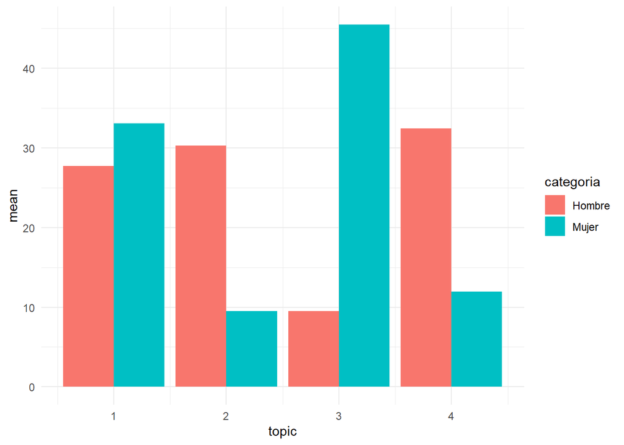

```r
doc_2_topics %>%
  rename(id = document) %>% # tenemos que renombrar la columna para que pueda hacerse el join
  mutate(id = as.integer(id)) %>%
  left_join(revistas %>% select(id, categoria) %>% unique()) %>%
  group_by(categoria, topic) %>%
    summarise(mean = mean(gamma)*100
              ) %>%
  ggplot() +
    geom_col(aes(x=topic, y=mean, fill=categoria), position='dodge') +
    theme_minimal()
```

Vemos cómo las revistas de mujeres parecen concentrarse en los tópicos 1 y 3, mientras que las de hombres, en los tópicos 1, 2 y 4. Siendo el tópico 3 el menos relevante.